# 2021 Version of the Multi-level Lockdown Model

Andrew Mitchell

05/05/2021

## Reporting

We will be using the TRIPOD (Transparent reporting of multivariable prediction model for individual prognosis or diagnosis) framework for reporting the model development, validation, and results.

## Outcome

### 6a Clearly define the outcome that is predicted by the prediction model, including how and when assessed.

This study involves predicting five outcome variables, through five separately constructed models. These outcomes are survey responses as collected according to the SSID protocol through in-situ questionnaires in various urban public spaces. The five outcome variables are:

1. `Pleasant` - from (-1, 1) derived from the 8 PAQs according to ISO 12913 Part 3
2. `Eventful` - from (-1, 1) derived from the 8 PAQs according to ISO 12913 Part 3
3. `Human` - from (1, 5) survey response regarding the relative presence/dominance of human sounds
4. `Traffic` - from (1, 5) survey response regarding the relative presence/dominance of traffic sounds
5. `Natural` - from (1, 5) survey response regarding the relative presence/dominance of natural sounds

### 6b Report any actions to blind assessment of the outcome to be predicted

N/A

## Predictors

### 7a Clearly define all predictors used in developing or validating the multivariable prediction model, including how and when they were measured.

The acoustic predictors are derived from the 30s binaural recordings taken during the SSID Protocol. The (psycho)acoustic metrics considered are:

- Loudness ($N_5$, sones)
- Sharpness (acum)
- Roughness (asper)
- Impulsiveness (iu)
- Fluctuation Strength (vacil)
- $L_{Aeq,30s}$ (dB)
- $L_{A10} - L_{A90}$ (dB)
- $L_{Ceq} - L_{Aeq}$ (dB)
- Speech Interference Level ($SIL3_{50}$, dB)

```r
init_features <- c("Loudness_N5(soneGF)", "Sharpness_S(acum)", "Rough_HM_R(asper)", "I_HM_I(iu)", "FS_(vacil)", "LAeq_L(A)(dB(SPL))", "LA10_LA90(dB(SPL))", "LCeq_LAeq(dB(SPL))", "SIL3_Avg,arith(dB(SPL))")
init_feature_string <- paste(init_features, collapse = " + ")
init_feature_string
```

```
## [1] "Loudness_N5(soneGF) + Sharpness_S(acum) + Rough_HM_R(asper) + I_HM_I(iu) + FS_(vacil) + LAeq_L(A)(dB(SPL)) + LA10_LA90(dB(SPL)) + LCeq_LAeq(dB(SPL)) + SIL3_Avg,arith(dB(SPL))"
```

## Sample Size

### 8 Explain how the study size was arrived at.

(Covered in the manuscript already)

```r
library(glue)
library(tidyr)
library(here)
library(knitr)
library(dplyr)

library(readxl)
data <- read_excel(here("data", "2021-05-05", "SSID Europe Database V1.0.xlsx"), sheet = "Master Merge")
data <- as_tibble(data)
data <- data[c("GroupID", "LocationID", "Lockdown", "ISOPleasant", "ISOEventful", "Human", "Traffic", "Natural", init_features)]

data <- rename(data, "N5" = "Loudness_N5(soneGF)")
data <- rename(data, "S" = "Sharpness_S(acum)")
data <- rename(data, "R" = "Rough_HM_R(asper)")
data <- rename(data, "I" = "I_HM_I(iu)")
data <- rename(data, "FS" = "FS_(vacil)")
data <- rename(data, "LAeq" = "LAeq_L(A)(dB(SPL))")
data <- rename(data, "LA10_LA90" = "LA10_LA90(dB(SPL))")
data <- rename(data, "LCeq_LAeq" = "LCeq_LAeq(dB(SPL))")
data <- rename(data, "SIL3" = "SIL3_Avg,arith(dB(SPL))")

features <- c("N5", "S", "R", "I", "FS", "LAeq", "LA10_LA90", "LCeq_LAeq", "SIL3")
feature_string <- paste(features, collapse = " + ")
feature_string
```

```
## [1] "N5 + S + R + I + FS + LAeq + LA10_LA90 + LCeq_LAeq + SIL3"
```

```r
locations <- c("CamdenTown", "EustonTap", "MarchmontGarden", "MonumentoGaribaldi", "PancrasLock", "RegentsParkFields", "RegentsParkJapan", "RussellSq", "SanMarco", "StPaulsCross", "StPaulsRow", "TateModern", "TorringtonSq")

data <- data %>%
    filter(LocationID %in% locations)

print("Full data table has dimensions: ")
```

```
## [1] "Full data table has dimensions: "
```

```r
print(dim(data))
```

```
## [1] 1909   17
```

```r
kable(print(head(data)))
```

```
## # A tibble: 6 x 17
##   GroupID LocationID Lockdown ISOPleasant ISOEventful Human Traffic Natural
##   <chr>   <chr>         <dbl>       <dbl>       <dbl> <dbl>   <dbl>   <dbl>
## 1 CT101   CamdenTown        1     -0.220        0.427     3       4       2
## 2 CT101   CamdenTown        1     -0.470        0.177     4       4       2
## 3 CT101   CamdenTown        1      0            0.25      2       3       1
## 4 CT102   CamdenTown        1      0.104       -0.75      4       3       1
## 5 CT103   CamdenTown        1      0.25         0.75      4       4       1
## 6 CT104   CamdenTown        1      0.0732       0.677     2       4       1
## # ... with 9 more variables: N5 <dbl>, S <dbl>, R <dbl>, I <dbl>, FS <dbl>,
## #   LAeq <dbl>, LA10_LA90 <dbl>, LCeq_LAeq <dbl>, SIL3 <dbl>
```

| GroupID | LocationID | Lockdown | ISOPleasant | ISOEventful | Human | Traffic | Natural | N5 | S | R | I | FS | LAeq | LA10_LA90 | LCeq_LAeq | SIL3 |
| --- | --- | --- | --- | --- | --- | --- | --- | --- | --- | --- | --- | --- | --- | --- | --- | --- |
| CT101 | CamdenTown | 1 | -0.2197 | 0.4268 | 3 | 4 | 2 | 31.1 | 2.14 | 0.0374 | 0.358 | 0.01700 | 70.07 | 7.78 | 7.81 | 59.59 |
| CT101 | CamdenTown | 1 | -0.4697 | 0.1768 | 4 | 4 | 2 | 31.1 | 2.14 | 0.0374 | 0.358 | 0.01700 | 70.07 | 7.78 | 7.81 | 59.59 |
| CT101 | CamdenTown | 1 | 0.0000 | 0.2500 | 2 | 3 | 1 | 31.1 | 2.14 | 0.0374 | 0.358 | 0.01700 | 70.07 | 7.78 | 7.81 | 59.59 |
| CT102 | CamdenTown | 1 | 0.1036 | -0.7500 | 4 | 3 | 1 | 34.4 | 2.18 | 0.0446 | 0.362 | 0.01790 | 71.26 | 8.38 | 6.25 | 60.15 |
| CT103 | CamdenTown | 1 | 0.2500 | 0.7500 | 4 | 4 | 1 | 24.7 | 2.00 | 0.0369 | 0.370 | 0.00889 | 66.71 | 4.23 | 7.61 | 56.45 |
| CT104 | CamdenTown | 1 | 0.0732 | 0.6768 | 2 | 4 | 1 | 38.6 | 2.37 | 0.0413 | 0.393 | 0.01460 | 72.47 | 6.97 | 6.32 | 62.72 |

## Missing Data

### 9 Describe how missing data were handled (e.g. complete-case analysis, single imputation, multiple imputation) with details of any imputation method

#### Dealing with PAQ missing data

According to our data quality rules, any survey responses with more than half of the PAQ responses missing were excluded whole-sale. Otherwise, where PAQ responses are missing, they are given a value of 3 (Neutral) prior to the ISO trigonometric projection to the complex Pleasantness and Eventfulness values.

#### Missing Sound Source data

Survey responses missing a response for the target outcome are excluded only from that model. e.g. a response may be missing only the Natural sound question - it is excluded only from the Natural model and will be included in all other models (e.g. Traffic, Human, Pleasant,)

#### Missing acoustic data

Only responses which have a corresponding recording are included in this dataset, therefore there is no missing acoustic data for a given survey response.

## Statistical Analysis Methods

### 10a Describe how predictors were handled in the analyses

```r
data <- data %>% mutate_at(vars(GroupID, LocationID, Lockdown), funs(as.factor))
data <- data %>% mutate_at(vars(c("ISOPleasant", "ISOEventful", "Traffic", "Human", "Natural", features)), funs(as.numeric))
kable(head(data))
```

| GroupID | LocationID | Lockdown | ISOPleasant | ISOEventful | Human | Traffic | Natural | N5 | S | R | I | FS | LAeq | LA10_LA90 | LCeq_LAeq | SIL3 |
| --- | --- | --- | --- | --- | --- | --- | --- | --- | --- | --- | --- | --- | --- | --- | --- | --- |
| CT101 | CamdenTown | 1 | -0.2197 | 0.4268 | 3 | 4 | 2 | 31.1 | 2.14 | 0.0374 | 0.358 | 0.01700 | 70.07 | 7.78 | 7.81 | 59.59 |
| CT101 | CamdenTown | 1 | -0.4697 | 0.1768 | 4 | 4 | 2 | 31.1 | 2.14 | 0.0374 | 0.358 | 0.01700 | 70.07 | 7.78 | 7.81 | 59.59 |
| CT101 | CamdenTown | 1 | 0.0000 | 0.2500 | 2 | 3 | 1 | 31.1 | 2.14 | 0.0374 | 0.358 | 0.01700 | 70.07 | 7.78 | 7.81 | 59.59 |
| CT102 | CamdenTown | 1 | 0.1036 | -0.7500 | 4 | 3 | 1 | 34.4 | 2.18 | 0.0446 | 0.362 | 0.01790 | 71.26 | 8.38 | 6.25 | 60.15 |
| CT103 | CamdenTown | 1 | 0.2500 | 0.7500 | 4 | 4 | 1 | 24.7 | 2.00 | 0.0369 | 0.370 | 0.00889 | 66.71 | 4.23 | 7.61 | 56.45 |
| CT104 | CamdenTown | 1 | 0.0732 | 0.6768 | 2 | 4 | 1 | 38.6 | 2.37 | 0.0413 | 0.393 | 0.01460 | 72.47 | 6.97 | 6.32 | 62.72 |

### 10b Specify type of model, all model-building procedures (including any predictor selection), and method for internal validation.

#### Train-test split

We use an 80/20 train/test split. The splits are balanced within each LocationID so that we are randomly sampling from each location equally.

```r
prelockdownData <- data %>% filter(Lockdown == 1)
lockdownData <- data %>% filter(Lockdown == 2)

prelockdownData <- drop_na(prelockdownData)
prelockdownData[c(features)] <- scale(prelockdownData[c(features)])

# Train-test split
library(groupdata2)
set.seed(42)

parts = partition(prelockdownData, p=0.2, cat_col="LocationID")

train = parts[[2]]
test = parts[[1]]
kable(summary(train))
```

|  | GroupID | LocationID | Lockdown | ISOPleasant | ISOEventful | Human | Traffic | Natural | N5 | S | R | I | FS | LAeq | LA10_LA90 | LCeq_LAeq | SIL3 |
| --- | --- | --- | --- | --- | --- | --- | --- | --- | --- | --- | --- | --- | --- | --- | --- | --- | --- |
|  | PL107 : 17 | RussellSq :118 | 1:913 | Min. :-1.0000 | Min. :-0.7500 | Min. :1.000 | Min. :1.000 | Min. :1.000 | Min. :-1.430874 | Min. :-1.596921 | Min. :-1.70658 | Min. :-2.68631 | Min. :-0.988457 | Min. :-2.217798 | Min. :-1.72797 | Min. :-2.152720 | Min. :-2.084349 |
|  | RS324 : 7 | TateModern :103 | NA | 1st Qu.:-0.0429 | 1st Qu.:-0.1036 | 1st Qu.:2.000 | 1st Qu.:2.000 | 1st Qu.:2.000 | 1st Qu.:-0.696257 | 1st Qu.:-0.722401 | 1st Qu.:-0.58213 | 1st Qu.:-0.71742 | 1st Qu.:-0.529837 | 1st Qu.:-0.664315 | 1st Qu.:-0.59763 | 1st Qu.:-0.727013 | 1st Qu.:-0.709580 |
|  | CT412 : 5 | RegentsParkFields: 85 | NA | Median : 0.2803 | Median : 0.1036 | Median :3.000 | Median :3.000 | Median :2.000 | Median :-0.168687 | Median :-0.222675 | Median :-0.14484 | Median :-0.12279 | Median :-0.259105 | Median : 0.012061 | Median :-0.14096 | Median :-0.035127 | Median :-0.017917 |
|  | SM314 : 5 | TorringtonSq : 83 | NA | Mean : 0.2447 | Mean : 0.1352 | Mean :3.107 | Mean :2.696 | Mean :2.507 | Mean : 0.005224 | Mean :-0.009005 | Mean : 0.01987 | Mean : 0.01012 | Mean :-0.006969 | Mean : 0.004139 | Mean : 0.01243 | Mean :-0.003121 | Mean : 0.002056 |
|  | TS426 : 5 | EustonTap : 76 | NA | 3rd Qu.: 0.5607 | 3rd Qu.: 0.3536 | 3rd Qu.:4.000 | 3rd Qu.:4.000 | 3rd Qu.:3.000 | 3rd Qu.: 0.538059 | 3rd Qu.: 0.381160 | 3rd Qu.: 0.44863 | 3rd Qu.: 0.49827 | 3rd Qu.: 0.217383 | 3rd Qu.: 0.686982 | 3rd Qu.: 0.45173 | 3rd Qu.: 0.686712 | 3rd Qu.: 0.829191 |
|  | ET306 : 4 | CamdenTown : 72 | NA | Max. : 1.0000 | Max. : 1.0000 | Max. :5.000 | Max. :5.000 | Max. :5.000 | Max. : 5.813762 | Max. : 5.961431 | Max. : 9.52758 | Max. : 9.37807 | Max. :11.274075 | Max. : 3.325576 | Max. : 5.23543 | Max. : 3.714840 | Max. : 3.591564 |
|  | (Other):870 | (Other) :376 | NA | NA | NA | NA | NA | NA | NA | NA | NA | NA | NA | NA | NA | NA | NA |

```r
kable(summary(test))
```

|  | GroupID | LocationID | Lockdown | ISOPleasant | ISOEventful | Human | Traffic | Natural | N5 | S | R | I | FS | LAeq | LA10_LA90 | LCeq_LAeq | SIL3 |
| --- | --- | --- | --- | --- | --- | --- | --- | --- | --- | --- | --- | --- | --- | --- | --- | --- | --- |
|  | PL107 : 7 | RussellSq :29 | 1:222 | Min. :-1.0000 | Min. :-0.6464 | Min. :1.000 | Min. :1.000 | Min. :1.000 | Min. :-1.43187 | Min. :-1.45117 | Min. :-1.76905 | Min. :-1.4970 | Min. :-0.92294 | Min. :-2.22216 | Min. :-1.69882 | Min. :-2.29349 | Min. :-2.084349 |
|  | RP110 : 3 | TateModern :25 | NA | 1st Qu.: 0.0000 | 1st Qu.:-0.0303 | 1st Qu.:2.000 | 1st Qu.:2.000 | 1st Qu.:1.250 | 1st Qu.:-0.69626 | 1st Qu.:-0.72240 | 1st Qu.:-0.62898 | 1st Qu.:-0.6613 | 1st Qu.:-0.53525 | 1st Qu.:-0.68322 | 1st Qu.:-0.61706 | 1st Qu.:-0.75921 | 1st Qu.:-0.709580 |
|  | SM308 : 3 | RegentsParkFields:21 | NA | Median : 0.3536 | Median : 0.1464 | Median :3.000 | Median :3.000 | Median :2.000 | Median :-0.12887 | Median :-0.22268 | Median :-0.17087 | Median :-0.1294 | Median :-0.26993 | Median : 0.05424 | Median :-0.14258 | Median : 0.07120 | Median : 0.027005 |
|  | ET109 : 2 | TorringtonSq :20 | NA | Mean : 0.2949 | Mean : 0.1473 | Mean :3.144 | Mean :2.653 | Mean :2.459 | Mean :-0.02149 | Mean : 0.03704 | Mean :-0.08171 | Mean :-0.0416 | Mean : 0.02866 | Mean :-0.01702 | Mean :-0.05112 | Mean : 0.01284 | Mean :-0.008455 |
|  | ET118 : 2 | EustonTap :18 | NA | 3rd Qu.: 0.6036 | 3rd Qu.: 0.3504 | 3rd Qu.:4.000 | 3rd Qu.:4.000 | 3rd Qu.:3.000 | 3rd Qu.: 0.54304 | 3rd Qu.: 0.39678 | 3rd Qu.: 0.32109 | 3rd Qu.: 0.4289 | 3rd Qu.: 0.16594 | 3rd Qu.: 0.67644 | 3rd Qu.: 0.30842 | 3rd Qu.: 0.73389 | 3rd Qu.: 0.813148 |
|  | ET307 : 2 | MarchmontGarden :18 | NA | Max. : 1.0000 | Max. : 0.9268 | Max. :5.000 | Max. :5.000 | Max. :5.000 | Max. : 5.87349 | Max. : 4.58718 | Max. : 3.70747 | Max. : 4.0528 | Max. : 8.29602 | Max. : 3.04484 | Max. : 5.56254 | Max. : 3.46025 | Max. : 2.852840 |
|  | (Other):203 | (Other) :91 | NA | NA | NA | NA | NA | NA | NA | NA | NA | NA | NA | NA | NA | NA | NA |

## Pleasant Model

When this feature selection is performed with the entire feature set, it includes both LAeq and SIL3 at the end, which have a VIF > 10. Therefore, we remove one of them (LAeq) at the start before the feature selection is performed.

```r
Pleasant.results <- model.building(target="ISOPleasant", features = features, train.data = train, test.data = test, grp="LocationID", exclude.features = c("LAeq"))
```

```
## Backward reduced fixed-effect table:
## Degrees of freedom method: Satterthwaite
##
##           Eliminated  Sum Sq Mean Sq NumDF  DenDF F value    Pr(>F)
## LA10_LA90          1 0.00581 0.00581     1  14.88  0.0544   0.81868
## I                  2 0.01780 0.01780     1 878.80  0.1667   0.68315
## R                  3 0.23296 0.23296     1  33.21  2.1833   0.14894
## SIL3               4 0.28956 0.28956     1 119.04  2.7088   0.10244
## S                  5 0.18303 0.18303     1 218.40  1.7151   0.19170
## FS                 6 0.32427 0.32427     1 686.25  3.0427   0.08155 .
## N5                 0 2.05864 2.05864     1 279.55 19.2806 1.602e-05 ***
## ---
## Signif. codes:  0 '***' 0.001 '**' 0.01 '*' 0.05 '.' 0.1 ' ' 1
## Backward reduced random-effect table:
##
##                                                                Eliminated npar
## <none>                                                                      45
## S in (1 + N5 + S + R + I + FS + LA10_LA90 + SIL3 | LocationID)          1   37
## SIL3 in (N5 + R + I + FS + LA10_LA90 + SIL3 | LocationID)               2   30
## N5 in (N5 + R + I + FS + LA10_LA90 | LocationID)                        3   24
## I in (R + I + FS + LA10_LA90 | LocationID)                              4   19
## FS in (R + FS + LA10_LA90 | LocationID)                                 5   15
## R in (R + LA10_LA90 | LocationID)                                       0   12
## LA10_LA90 in (R + LA10_LA90 | LocationID)                               0   12
##                                                                 logLik    AIC
## <none>                                                         -307.40 704.80
## S in (1 + N5 + S + R + I + FS + LA10_LA90 + SIL3 | LocationID) -307.79 689.58
## SIL3 in (N5 + R + I + FS + LA10_LA90 + SIL3 | LocationID)      -309.10 678.20
## N5 in (N5 + R + I + FS + LA10_LA90 | LocationID)               -310.87 669.74
## I in (R + I + FS + LA10_LA90 | LocationID)                     -315.27 668.55
## FS in (R + FS + LA10_LA90 | LocationID)                        -317.44 664.89
## R in (R + LA10_LA90 | LocationID)                              -321.75 667.50
## LA10_LA90 in (R + LA10_LA90 | LocationID)                      -322.82 669.65
##                                                                    LRT Df
## <none>
## S in (1 + N5 + S + R + I + FS + LA10_LA90 + SIL3 | LocationID)  0.7858  8
## SIL3 in (N5 + R + I + FS + LA10_LA90 + SIL3 | LocationID)       2.6180  7
## N5 in (N5 + R + I + FS + LA10_LA90 | LocationID)                3.5384  6
## I in (R + I + FS + LA10_LA90 | LocationID)                      8.8066  5
## FS in (R + FS + LA10_LA90 | LocationID)                         4.3426  4
```

[output cut: 29 more lines]

```
##  Residual               0.106772 0.32676
## Number of obs: 913, groups:  LocationID, 13
##
## Fixed effects:
##              Estimate Std. Error        df t value Pr(>|t|)
## (Intercept)   0.23376    0.05054  11.87611   4.625 0.000601 ***
## N5           -0.07939    0.01808 279.55213  -4.391  1.6e-05 ***
## ---
## Signif. codes:  0 '***' 0.001 '**' 0.01 '*' 0.05 '.' 0.1 ' ' 1
##
## Correlation of Fixed Effects:
##    (Intr)
## N5 -0.124
## optimizer (nloptwrap) convergence code: 0 (OK)
## boundary (singular) fit: see ?isSingular
```

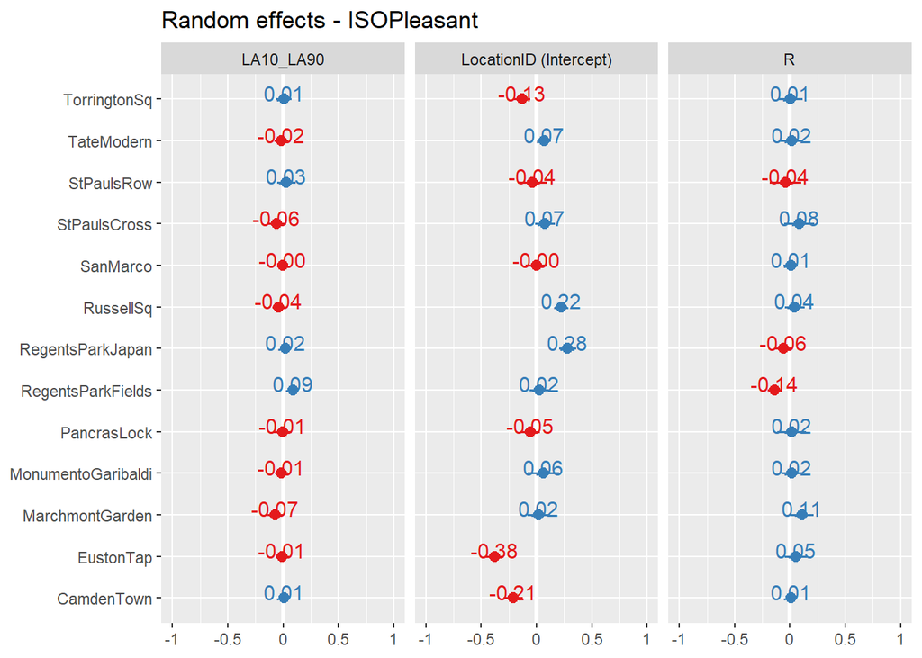

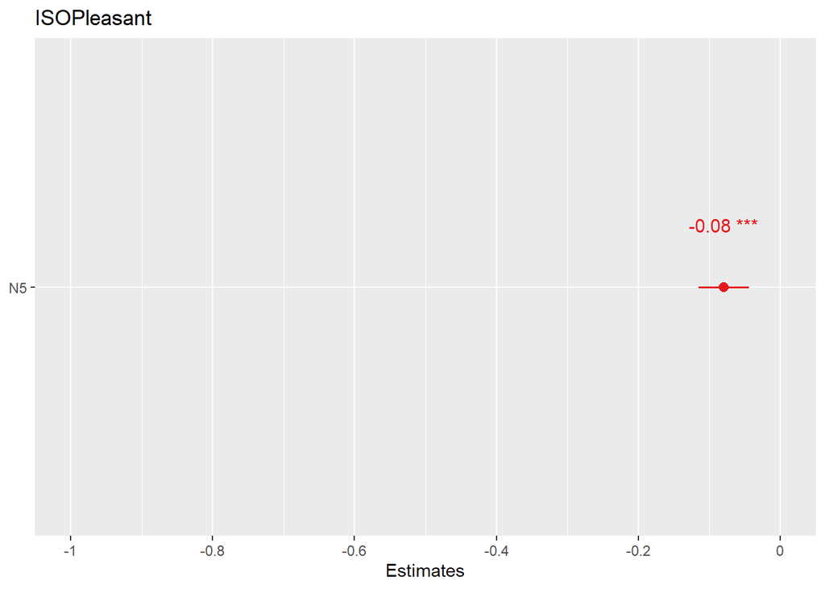

```
##             R2m       R2c
## [1,] 0.04139854 0.2961566
```

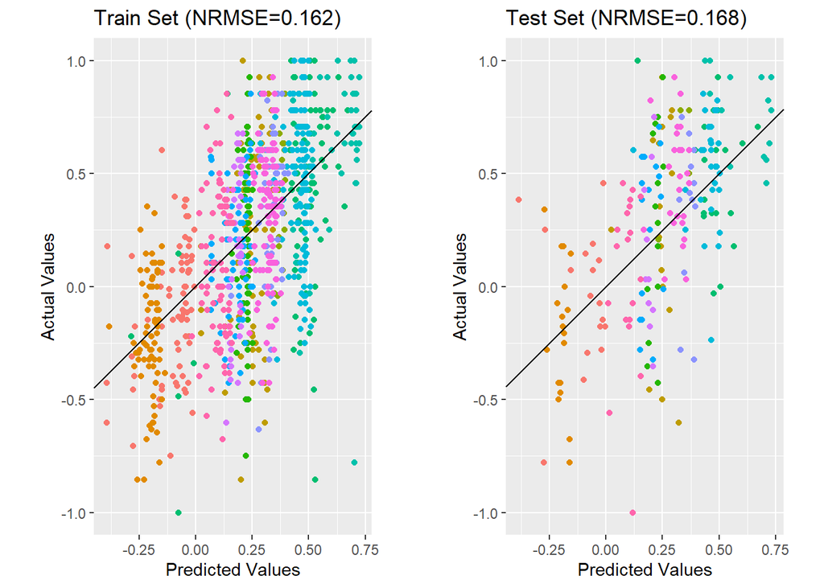

## Eventful Model

```r
Eventful.results <- model.building(target="ISOEventful", features = features, train.data = train, test.data = test, grp="LocationID")
```

```
## Backward reduced fixed-effect table:
## Degrees of freedom method: Satterthwaite
##
##           Eliminated Sum Sq Mean Sq NumDF  DenDF F value    Pr(>F)
## R                  1 0.0000  0.0000     1 874.86  0.0001   0.99112
## LA10_LA90          2 0.0002  0.0002     1 135.10  0.0022   0.96243
## N5                 3 0.0089  0.0089     1  78.59  0.1090   0.74213
## I                  4 0.0299  0.0299     1 472.47  0.3644   0.54635
## FS                 5 0.0150  0.0150     1  16.15  0.1825   0.67491
## LAeq               6 0.1770  0.1770     1 371.45  2.1610   0.14240
## LCeq_LAeq          7 0.2742  0.2742     1 242.88  3.3442   0.06867 .
## S                  0 2.8209  2.8209     1  36.63 34.3850 9.940e-07 ***
## SIL3               0 6.4853  6.4853     1   9.03 79.0501 9.231e-06 ***
## ---
## Signif. codes:  0 '***' 0.001 '**' 0.01 '*' 0.05 '.' 0.1 ' ' 1
## Backward reduced random-effect table:
##
##                                                                                    Eliminated
## <none>
## N5 in (1 + N5 + S + R + I + FS + LAeq + LA10_LA90 + LCeq_LAeq + SIL3 | LocationID)          1
## LCeq_LAeq in (S + R + I + FS + LAeq + LA10_LA90 + LCeq_LAeq + SIL3 | LocationID)            2
## LA10_LA90 in (S + R + I + FS + LAeq + LA10_LA90 + SIL3 | LocationID)                        3
## R in (S + R + I + FS + LAeq + SIL3 | LocationID)                                            4
## S in (S + I + FS + LAeq + SIL3 | LocationID)                                                5
## I in (I + FS + LAeq + SIL3 | LocationID)                                                    6
## SIL3 in (FS + LAeq + SIL3 | LocationID)                                                     7
## FS in (FS + LAeq | LocationID)                                                              0
## LAeq in (FS + LAeq | LocationID)                                                            0
##                                                                                    npar
## <none>                                                                               66
## N5 in (1 + N5 + S + R + I + FS + LAeq + LA10_LA90 + LCeq_LAeq + SIL3 | LocationID)   56
## LCeq_LAeq in (S + R + I + FS + LAeq + LA10_LA90 + LCeq_LAeq + SIL3 | LocationID)     47
## LA10_LA90 in (S + R + I + FS + LAeq + LA10_LA90 + SIL3 | LocationID)                 39
## R in (S + R + I + FS + LAeq + SIL3 | LocationID)                                     32
## S in (S + I + FS + LAeq + SIL3 | LocationID)                                         26
## I in (I + FS + LAeq + SIL3 | LocationID)                                             21
## SIL3 in (FS + LAeq + SIL3 | LocationID)                                              17
## FS in (FS + LAeq | LocationID)                                                       14
## LAeq in (FS + LAeq | LocationID)                                                     14
##                                                                                     logLik
```

[output cut: 85 more lines]

```
##
## Fixed effects:
##             Estimate Std. Error       df t value Pr(>|t|)
## (Intercept)  0.12911    0.01694 10.66795   7.621 1.24e-05 ***
## S           -0.11578    0.01974 36.63250  -5.864 9.94e-07 ***
## SIL3         0.18032    0.02028  9.02919   8.891 9.23e-06 ***
## ---
## Signif. codes:  0 '***' 0.001 '**' 0.01 '*' 0.05 '.' 0.1 ' ' 1
##
## Correlation of Fixed Effects:
##      (Intr) S
## S     0.054
## SIL3  0.243 -0.658
## optimizer (nloptwrap) convergence code: 0 (OK)
## boundary (singular) fit: see ?isSingular
```

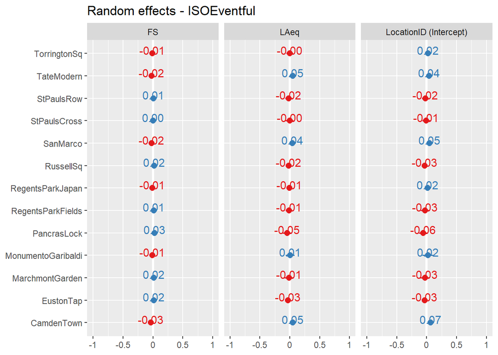

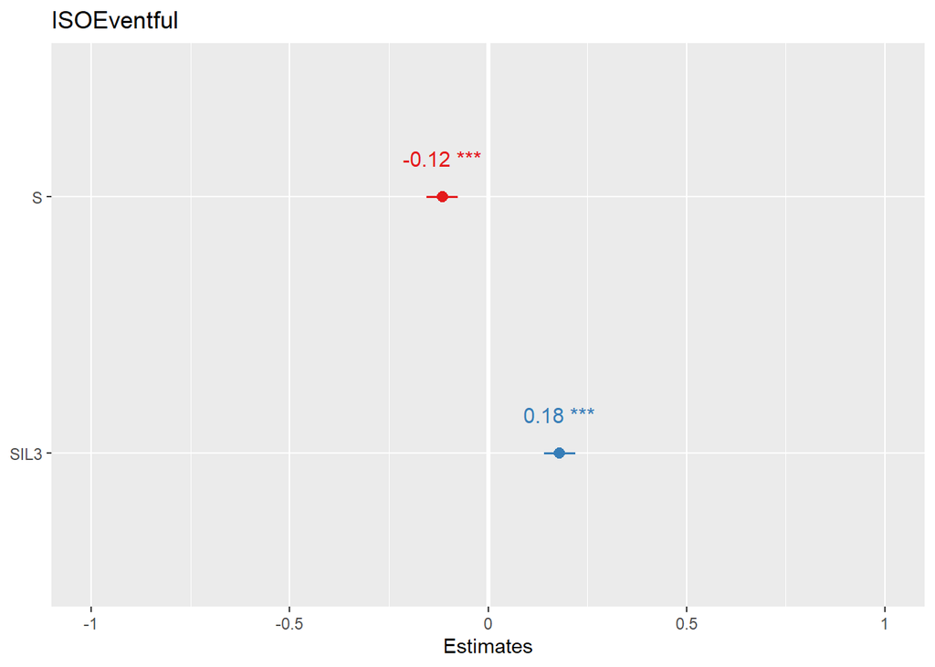

```
##            R2m       R2c
## [1,] 0.1571545 0.1980286
```

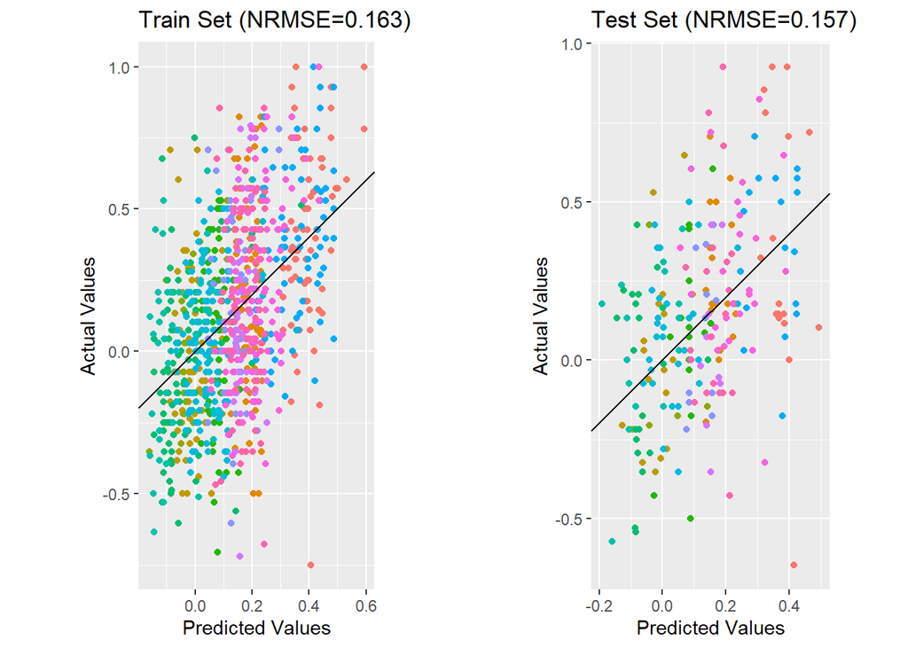

```r
sjPlot::tab_model(Pleasant.results$model, Eventful.results$model)
```

|  | ISOPleasant |  |  | ISOEventful |  |  |
| --- | --- | --- | --- | --- | --- | --- |
| Predictors | Estimates | CI | p | Estimates | CI | p |
| (Intercept) | 0.23 | 0.13 – 0.33 | **<0.001** | 0.13 | 0.10 – 0.16 | **<0.001** |
| N5 | -0.08 | -0.11 – -0.04 | **<0.001** |  |  |  |
| S |  |  |  | -0.12 | -0.15 – -0.08 | **<0.001** |
| SIL3 |  |  |  | 0.18 | 0.14 – 0.22 | **<0.001** |
| Random Effects |  |  |  |  |  |  |
| σ<sup>2</sup> | 0.11 |  |  | 0.08 |  |  |
| τ<sub>00</sub> | 0.03 <sub>LocationID</sub> |  |  | 0.00 <sub>LocationID</sub> |  |  |
| τ<sub>11</sub> | 0.01 <sub>LocationID.R</sub> |  |  | 0.00 <sub>LocationID.FS</sub> |  |  |
|  | 0.00 <sub>LocationID.LA10_LA90</sub> |  |  | 0.00 <sub>LocationID.LAeq</sub> |  |  |
| ρ<sub>01</sub> | -0.13 |  |  | -1.00 |  |  |
|  | -0.10 |  |  | 0.82 |  |  |
| N | 13 <sub>LocationID</sub> |  |  | 13 <sub>LocationID</sub> |  |  |
| Observations | 913 |  |  | 913 |  |  |
| Marginal R<sup>2</sup> / Conditional R<sup>2</sup> | 0.056 / NA |  |  | 0.164 / NA |  |  |

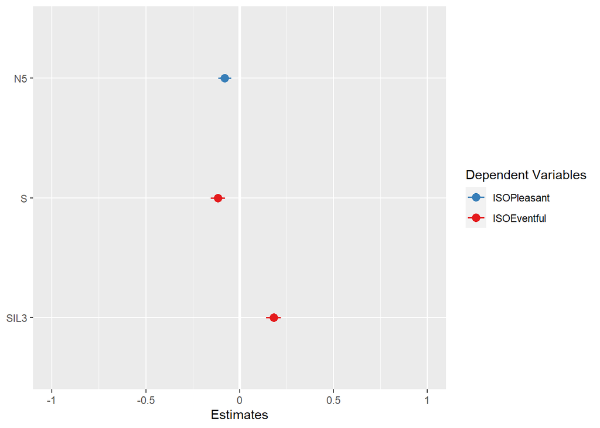

```r
sjPlot::plot_models(Pleasant.results$model, Eventful.results$model)
```

## Natural Model

```r
Natural.results <- model.building(target="Natural", features = features, train.data = train, test.data = test, grp="LocationID")
```

```
## Backward reduced fixed-effect table:
## Degrees of freedom method: Satterthwaite
##
##           Eliminated Sum Sq Mean Sq NumDF  DenDF F value    Pr(>F)
## LAeq               1  0.015   0.015     1 889.33  0.0168  0.896865
## I                  2  0.080   0.080     1 818.47  0.0900  0.764315
## LA10_LA90          3  0.166   0.166     1 895.45  0.1875  0.665093
## R                  4  0.111   0.111     1 904.63  0.1254  0.723285
## N5                 5  0.819   0.819     1 507.97  0.9247  0.336702
## FS                 6  3.235   3.235     1 866.32  3.6508  0.056372 .
## S                  0 12.130  12.130     1  54.44 13.6695  0.000508 ***
## LCeq_LAeq          0  5.562   5.562     1 643.13  6.2682  0.012539 *
## SIL3               0 39.429  39.429     1 156.33 44.4329 4.272e-10 ***
## ---
## Signif. codes:  0 '***' 0.001 '**' 0.01 '*' 0.05 '.' 0.1 ' ' 1
## Backward reduced random-effect table:
##
##                                                                                   Eliminated
## <none>
## R in (1 + N5 + S + R + I + FS + LAeq + LA10_LA90 + LCeq_LAeq + SIL3 | LocationID)          1
## N5 in (N5 + S + I + FS + LAeq + LA10_LA90 + LCeq_LAeq + SIL3 | LocationID)                 2
## LCeq_LAeq in (S + I + FS + LAeq + LA10_LA90 + LCeq_LAeq + SIL3 | LocationID)               3
## FS in (S + I + FS + LAeq + LA10_LA90 + SIL3 | LocationID)                                  4
## SIL3 in (S + I + LAeq + LA10_LA90 + SIL3 | LocationID)                                     5
## LAeq in (S + I + LAeq + LA10_LA90 | LocationID)                                            6
## I in (S + I + LA10_LA90 | LocationID)                                                      7
## LA10_LA90 in (S + LA10_LA90 | LocationID)                                                  8
## S in (S | LocationID)                                                                      0
##                                                                                   npar
## <none>                                                                              66
## R in (1 + N5 + S + R + I + FS + LAeq + LA10_LA90 + LCeq_LAeq + SIL3 | LocationID)   56
## N5 in (N5 + S + I + FS + LAeq + LA10_LA90 + LCeq_LAeq + SIL3 | LocationID)          47
## LCeq_LAeq in (S + I + FS + LAeq + LA10_LA90 + LCeq_LAeq + SIL3 | LocationID)        39
## FS in (S + I + FS + LAeq + LA10_LA90 + SIL3 | LocationID)                           32
## SIL3 in (S + I + LAeq + LA10_LA90 + SIL3 | LocationID)                              26
## LAeq in (S + I + LAeq + LA10_LA90 | LocationID)                                     21
## I in (S + I + LA10_LA90 | LocationID)                                               17
## LA10_LA90 in (S + LA10_LA90 | LocationID)                                           14
## S in (S | LocationID)                                                               12
##                                                                                    logLik
```

[output cut: 86 more lines]

```
##              Estimate Std. Error        df t value Pr(>|t|)
## (Intercept)   2.44030    0.12086  10.54512  20.191 9.06e-10 ***
## S             0.34170    0.09242  54.43634   3.697 0.000508 ***
## LCeq_LAeq    -0.12768    0.05100 643.12727  -2.504 0.012539 *
## SIL3         -0.54859    0.08230 156.33332  -6.666 4.27e-10 ***
## ---
## Signif. codes:  0 '***' 0.001 '**' 0.01 '*' 0.05 '.' 0.1 ' ' 1
##
## Correlation of Fixed Effects:
##           (Intr) S      LCq_LA
## S          0.411
## LCeq_LAeq  0.067  0.192
## SIL3       0.023 -0.579  0.346
## optimizer (nloptwrap) convergence code: 0 (OK)
## boundary (singular) fit: see ?isSingular
```

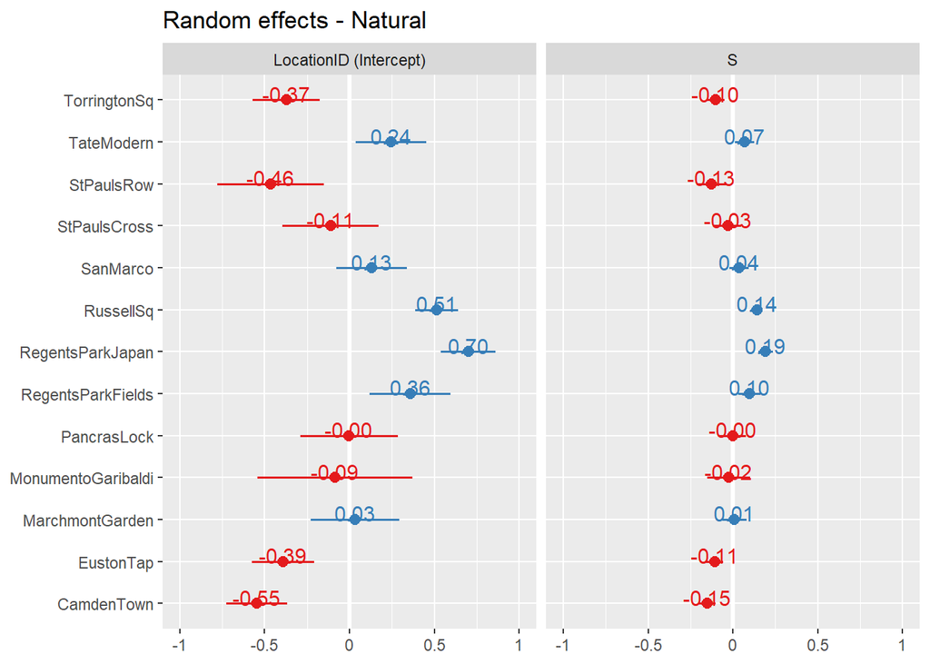

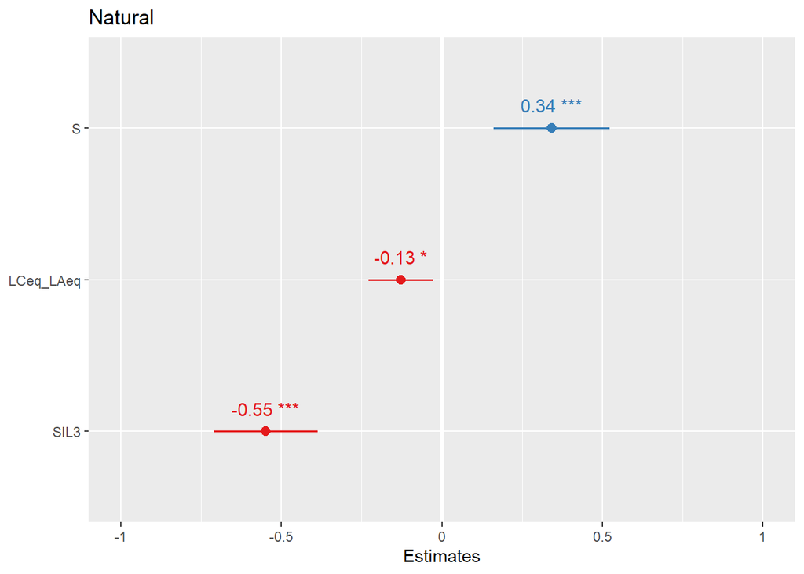

```
##            R2m      R2c
## [1,] 0.1055983 0.257409
```

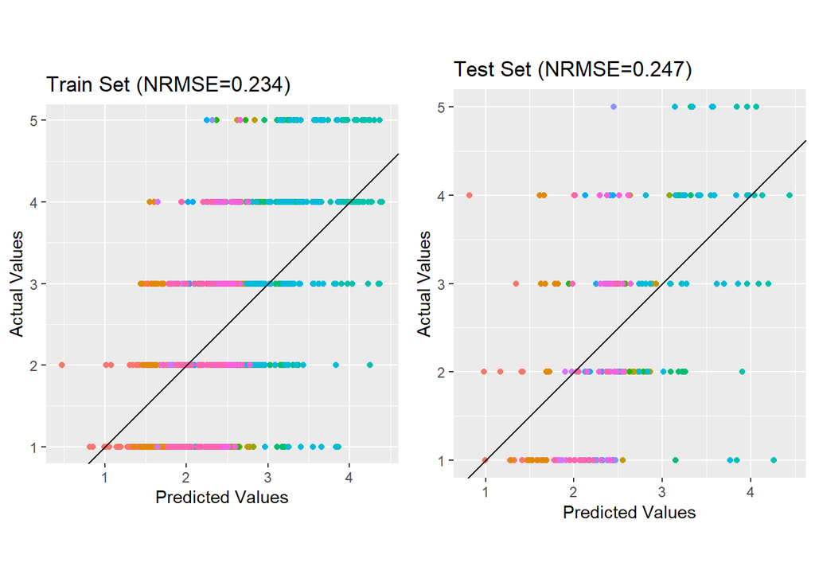

## Traffic Model

```r
Traffic.results <- model.building(target="Traffic", features = features, train.data = train, test.data = test, grp="LocationID", exclude.features = c("SIL3"))
```

```
## Backward reduced fixed-effect table:
## Degrees of freedom method: Satterthwaite
##
##           Eliminated  Sum Sq Mean Sq NumDF  DenDF F value  Pr(>F)
## LCeq_LAeq          1 0.00696 0.00696     1  14.56  0.0089 0.92626
## I                  2 0.07455 0.07455     1 810.80  0.0950 0.75796
## N5                 3 0.11565 0.11565     1 327.68  0.1476 0.70113
## LA10_LA90          4 0.22213 0.22213     1  24.99  0.2837 0.59900
## FS                 5 1.41982 1.41982     1 636.92  1.8140 0.17851
## R                  6 2.95770 2.95770     1  16.00  3.7708 0.06997 .
## S                  0 3.06158 3.06158     1 232.55  3.8908 0.04974 *
## LAeq               0 3.12175 3.12175     1  94.86  3.9673 0.04927 *
## ---
## Signif. codes:  0 '***' 0.001 '**' 0.01 '*' 0.05 '.' 0.1 ' ' 1
## Backward reduced random-effect table:
##
##                                                                               Eliminated
## <none>
## LAeq in (1 + N5 + S + R + I + FS + LAeq + LA10_LA90 + LCeq_LAeq | LocationID)          1
## I in (N5 + S + R + I + FS + LA10_LA90 + LCeq_LAeq | LocationID)                        2
## N5 in (N5 + S + R + FS + LA10_LA90 + LCeq_LAeq | LocationID)                           3
## FS in (S + R + FS + LA10_LA90 + LCeq_LAeq | LocationID)                                4
## S in (S + R + LA10_LA90 + LCeq_LAeq | LocationID)                                      5
## R in (R + LA10_LA90 + LCeq_LAeq | LocationID)                                          0
## LA10_LA90 in (R + LA10_LA90 + LCeq_LAeq | LocationID)                                  0
## LCeq_LAeq in (R + LA10_LA90 + LCeq_LAeq | LocationID)                                  0
##                                                                               npar
## <none>                                                                          55
## LAeq in (1 + N5 + S + R + I + FS + LAeq + LA10_LA90 + LCeq_LAeq | LocationID)   46
## I in (N5 + S + R + I + FS + LA10_LA90 + LCeq_LAeq | LocationID)                 38
## N5 in (N5 + S + R + FS + LA10_LA90 + LCeq_LAeq | LocationID)                    31
## FS in (S + R + FS + LA10_LA90 + LCeq_LAeq | LocationID)                         25
## S in (S + R + LA10_LA90 + LCeq_LAeq | LocationID)                               20
## R in (R + LA10_LA90 + LCeq_LAeq | LocationID)                                   16
## LA10_LA90 in (R + LA10_LA90 + LCeq_LAeq | LocationID)                           16
## LCeq_LAeq in (R + LA10_LA90 + LCeq_LAeq | LocationID)                           16
##                                                                                logLik
## <none>                                                                        -1228.9
## LAeq in (1 + N5 + S + R + I + FS + LAeq + LA10_LA90 + LCeq_LAeq | LocationID) -1230.0
## I in (N5 + S + R + I + FS + LA10_LA90 + LCeq_LAeq | LocationID)               -1230.8
```

[output cut: 77 more lines]

```
##
## Fixed effects:
##              Estimate Std. Error        df t value Pr(>|t|)
## (Intercept)   2.76163    0.19280  11.80779  14.323    8e-09 ***
## S             0.15859    0.08040 232.55184   1.973   0.0497 *
## LAeq         -0.15657    0.07861  94.86245  -1.992   0.0493 *
## ---
## Signif. codes:  0 '***' 0.001 '**' 0.01 '*' 0.05 '.' 0.1 ' ' 1
##
## Correlation of Fixed Effects:
##      (Intr) S
## S     0.067
## LAeq  0.070 -0.600
## optimizer (nloptwrap) convergence code: 0 (OK)
## boundary (singular) fit: see ?isSingular
```

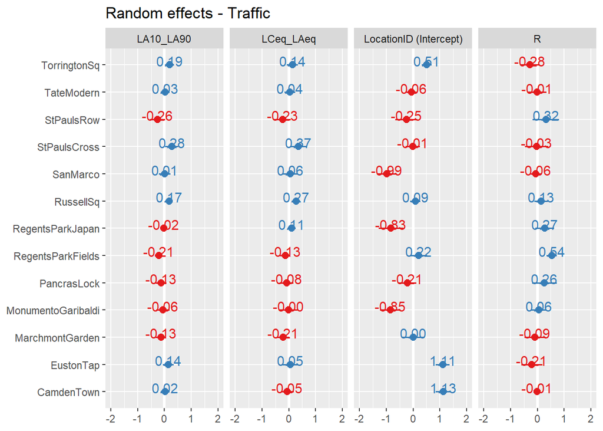

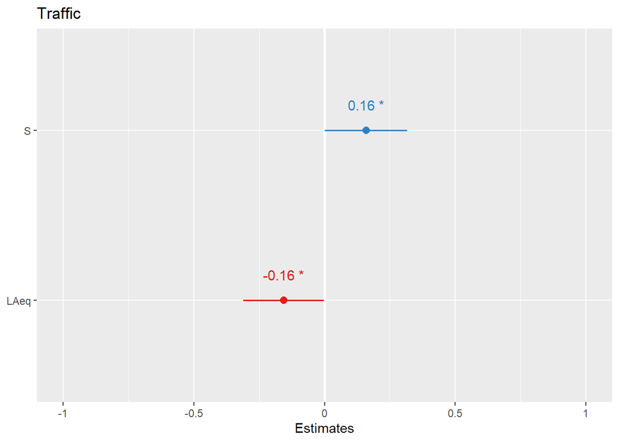

```
##             R2m       R2c
## [1,] 0.01530413 0.4462739
```

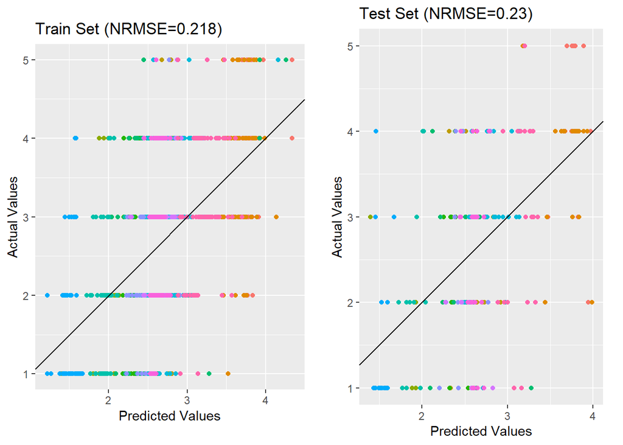

## Human Model

```r
Human.results <- model.building(target="Human", features = features, train.data = train, test.data = test, grp="LocationID")
```

```
## Backward reduced fixed-effect table:
## Degrees of freedom method: Satterthwaite
##
##           Eliminated  Sum Sq Mean Sq NumDF  DenDF F value  Pr(>F)
## LA10_LA90          1 0.00643 0.00643     1 557.27  0.0086 0.92632
## R                  2 0.03134 0.03134     1 891.66  0.0418 0.83804
## LCeq_LAeq          3 0.28276 0.28276     1 389.51  0.3775 0.53931
## LAeq               4 0.58915 0.58915     1 808.01  0.7873 0.37519
## FS                 5 0.83491 0.83491     1 339.10  1.1154 0.29166
## N5                 6 1.33155 1.33155     1 294.67  1.7790 0.18330
## SIL3               7 1.02424 1.02424     1  15.20  1.3672 0.26030
## I                  8 2.63489 2.63489     1 763.90  3.5175 0.06110 .
## S                  0 2.98914 2.98914     1 114.86  3.9815 0.04837 *
## ---
## Signif. codes:  0 '***' 0.001 '**' 0.01 '*' 0.05 '.' 0.1 ' ' 1
## Backward reduced random-effect table:
##
##                                                                                    Eliminated
## <none>
## N5 in (1 + N5 + S + R + I + FS + LAeq + LA10_LA90 + LCeq_LAeq + SIL3 | LocationID)          1
## LA10_LA90 in (S + R + I + FS + LAeq + LA10_LA90 + LCeq_LAeq + SIL3 | LocationID)            2
## FS in (S + R + I + FS + LAeq + LCeq_LAeq + SIL3 | LocationID)                               3
## R in (S + R + I + LAeq + LCeq_LAeq + SIL3 | LocationID)                                     4
## LCeq_LAeq in (S + I + LAeq + LCeq_LAeq + SIL3 | LocationID)                                 5
## LAeq in (S + I + LAeq + SIL3 | LocationID)                                                  6
## S in (S + I + SIL3 | LocationID)                                                            7
## I in (I + SIL3 | LocationID)                                                                8
## SIL3 in (SIL3 | LocationID)                                                                 0
##                                                                                    npar
## <none>                                                                               66
## N5 in (1 + N5 + S + R + I + FS + LAeq + LA10_LA90 + LCeq_LAeq + SIL3 | LocationID)   56
## LA10_LA90 in (S + R + I + FS + LAeq + LA10_LA90 + LCeq_LAeq + SIL3 | LocationID)     47
## FS in (S + R + I + FS + LAeq + LCeq_LAeq + SIL3 | LocationID)                        39
## R in (S + R + I + LAeq + LCeq_LAeq + SIL3 | LocationID)                              32
## LCeq_LAeq in (S + I + LAeq + LCeq_LAeq + SIL3 | LocationID)                          26
## LAeq in (S + I + LAeq + SIL3 | LocationID)                                           21
## S in (S + I + SIL3 | LocationID)                                                     17
## I in (I + SIL3 | LocationID)                                                         14
## SIL3 in (SIL3 | LocationID)                                                          12
##                                                                                     logLik
```

[output cut: 80 more lines]

```
##  LocationID (Intercept) 0.24056  0.4905
##             SIL3        0.05549  0.2356   0.99
##  Residual               0.75076  0.8665
## Number of obs: 913, groups:  LocationID, 13
##
## Fixed effects:
##              Estimate Std. Error        df t value Pr(>|t|)
## (Intercept)   2.89773    0.09615   8.71736  30.139 4.05e-10 ***
## S            -0.12632    0.06331 114.85810  -1.995   0.0484 *
## ---
## Signif. codes:  0 '***' 0.001 '**' 0.01 '*' 0.05 '.' 0.1 ' ' 1
##
## Correlation of Fixed Effects:
##   (Intr)
## S 0.647
```

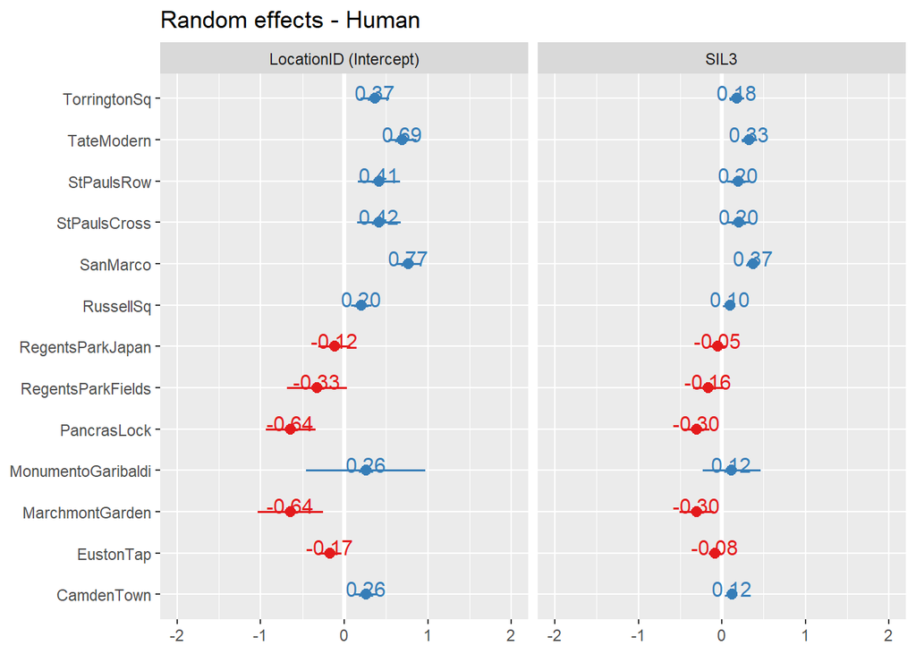

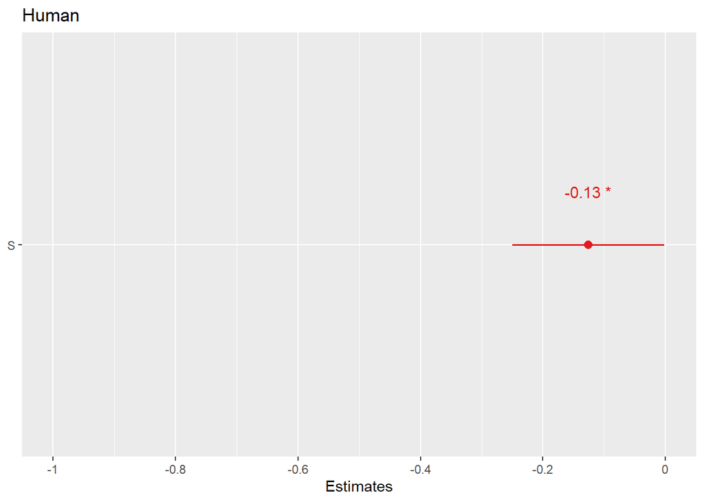

```
##             R2m       R2c
## [1,] 0.01472943 0.2936018
```

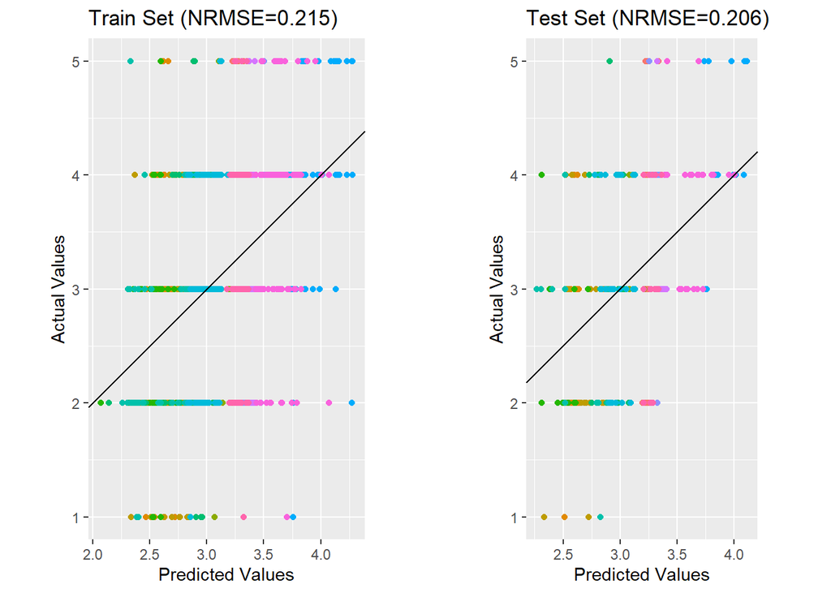

```r
sjPlot::tab_model(Natural.results$model, Traffic.results$model, Human.results$model)
```

|  | Natural |  |  | Traffic |  |  | Human |  |  |
| --- | --- | --- | --- | --- | --- | --- | --- | --- | --- |
| Predictors | Estimates | CI | p | Estimates | CI | p | Estimates | CI | p |
| (Intercept) | 2.44 | 2.20 – 2.68 | **<0.001** | 2.76 | 2.38 – 3.14 | **<0.001** | 2.90 | 2.71 – 3.09 | **<0.001** |
| S | 0.34 | 0.16 – 0.52 | **<0.001** | 0.16 | 0.00 – 0.32 | **0.049** | -0.13 | -0.25 – -0.00 | **0.046** |
| LCeq_LAeq | -0.13 | -0.23 – -0.03 | **0.012** |  |  |  |  |  |  |
| SIL3 | -0.55 | -0.71 – -0.39 | **<0.001** |  |  |  |  |  |  |
| LAeq |  |  |  | -0.16 | -0.31 – -0.00 | **0.046** |  |  |  |
| Random Effects |  |  |  |  |  |  |  |  |  |
| σ<sup>2</sup> | 0.89 |  |  | 0.79 |  |  | 0.75 |  |  |
| τ<sub>00</sub> | 0.17 <sub>LocationID</sub> |  |  | 0.47 <sub>LocationID</sub> |  |  | 0.24 <sub>LocationID</sub> |  |  |
| τ<sub>11</sub> | 0.01 <sub>LocationID.S</sub> |  |  | 0.08 <sub>LocationID.R</sub> |  |  | 0.06 <sub>LocationID.SIL3</sub> |  |  |
|  |  |  |  | 0.03 <sub>LocationID.LA10_LA90</sub> |  |  |  |  |  |
|  |  |  |  | 0.04 <sub>LocationID.LCeq_LAeq</sub> |  |  |  |  |  |
| ρ<sub>01</sub> | 1.00 <sub>LocationID</sub> |  |  | -0.23 |  |  | 0.99 <sub>LocationID</sub> |  |  |
|  |  |  |  | 0.24 |  |  |  |  |  |
|  |  |  |  | -0.02 |  |  |  |  |  |
| ICC |  |  |  | 0.37 |  |  | 0.24 |  |  |
| N | 13 <sub>LocationID</sub> |  |  | 13 <sub>LocationID</sub> |  |  | 13 <sub>LocationID</sub> |  |  |
| Observations | 913 |  |  | 913 |  |  | 913 |  |  |
| Marginal R<sup>2</sup> / Conditional R<sup>2</sup> | 0.124 / NA |  |  | 0.017 / 0.386 |  |  | 0.016 / 0.254 |  |  |

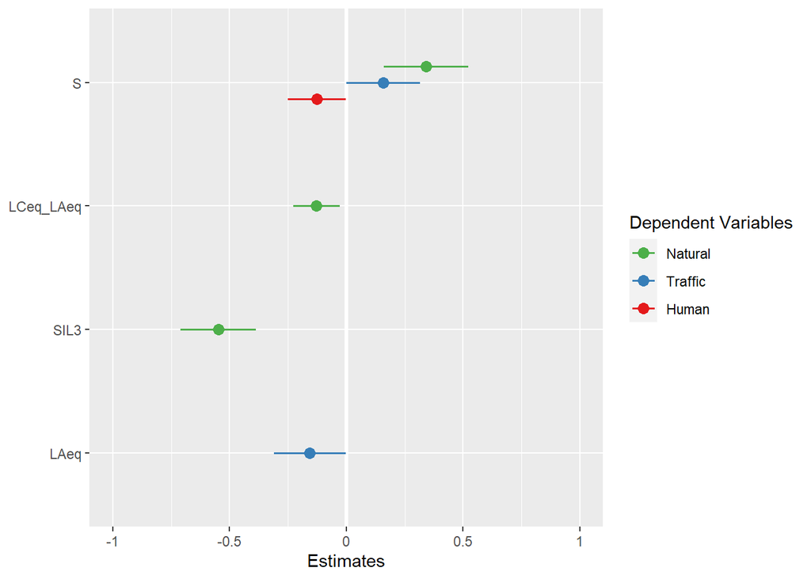

```r
sjPlot::plot_models(Natural.results$model, Traffic.results$model, Human.results$model)
```

##### Tried an attempt at Cross-validation -> not successful

### 5-fold CV

```r
# set.seed(42)
#
# Pleasant_formula <- as.formula(glue("ISOPleasant ~ 1 + ", feature_string, " + (1 + ", feature_string, "|LocationID)"))
# # init_Pleasant_model <- lmerTest::lmer(Pleasant_formula, data = train)
#
# prelockdownData$ID <- c(1:nrow(prelockdownData))
#
# # confusion_matrices <- list()
# models <- list()
# accuracy <- c()
#
# for (i in c(1:5)) {
#     # creating 5 random folds from the cancer data set
#     folds <- caret::createFolds(prelockdownData$ISOPleasant, k=5)
#
#     # Splitting the data into training and testing
#     test <- prelockdownData[prelockdownData$ID %in% folds[[i]], ]
#     train <- prelockdownData[prelockdownData$ID %in% unlist(folds[-i]), ]
#
#     # feature selection using lmerTest::step
#     init_Pleasant_model <- lmerTest::lmer(Pleasant_formula, data = train)
#     step_model <- lmerTest::step(init_Pleasant_model, data=train, reduce.random=TRUE)
#     step_model <- get_model(step_model)
#
#     models[[i]] <- step_model
#     accuracy[[i]] <- cAIC4::cAIC(step_model)
#
# }
```